# Ying and Hayden’s R tutorial - 2

Ying Chen and Hayden Wainwright, Lougheed Lab, Queen’s University

05/06/2020

## Preface

Welcome back my friends!

As another rock says **Smile!**.

We are glad you have lived through our first 3 sections (if not, [here is the material](https://htmlpreview.github.io/?https://github.com/YingChen94/BnR_Hayden_Ying_R_Session/blob/master/R_Hayden_Ying_20200429.html))!

- Section 1: R basics
- Section 2: Data simulation
- Section 3: Power analysis

We will continue with the following section 4 and 5 today!

- Section 4: Estimation statistics
- Section 5: Data visulization

Ready?

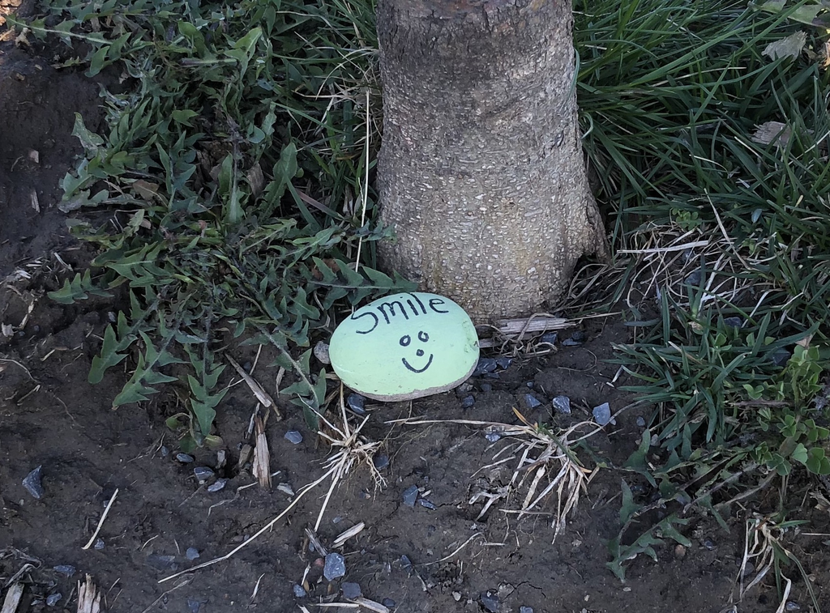

*You are my rock! Love from Lougheed Lab. Photo by Ying Chen.*

## Section 4. Estimation Statistics

*The following materials are prepared by Ying upon her understanding, which means they can be flawed.*

*Ying highly recommends you to read authoritative books and papers for learning. Here are some:*

- *Rothman, K. J. 1978. A show of confidence. New England Journal of Medicine 299(24): 1362-1363.*
- *Gardner, M. J., and D. G. Altman. 1986. British Medical Journal 292(6522): 746-750.*
- *Coe, R. 2002. It’s the effect size, stupid! What effect size is and why it is important. Annual Conference of the British Educational Research Association; University of Exeter, England.*
- *Sullivan, G. M., and R. Feinn. 2012. Using effect size — or why the p value is not enough. Journal of Graduate Medical Education 4(3): 279-282*
- *Wasserstein, R. L., A. L. Schirm, and N. A. Lazar. 2019. Moving to a world beyond “p < 0.05”. The American Statistician, 73:1-19.*
- *Halsey, L. G. 2019. The reign of the p-value is wver: What alternative analyses could we employ to fill the power vacuum? Biology Letters 15: 20190174*
- *Amrhein, V., S. Greenland, and B. Mcshane. 2019. Retire statistical significance. Nature 567:305-307.*

Problems of p-value and statistically significance:

- Dichotomy is not informative of the observed data (e.g. size of the difference between the groups), and can be misleading.

Alternatives:

- Bayesian analysis

Important concepts:

- Standard deviation: an descriptive index.
- Standard error: an estimative index.

**Package dabestr**

- Website: https://www.estimationstats.com/?fbclid=IwAR0d6nqcf3IbNgSb772R3TnzL4Nv7AtQFmLNToBvISmQmEMFyyVF6FdJ-lc#/background
- Official release on CRAN: https://cran.r-project.org/web/packages/dabestr/index.html
- Github link: https://github.com/ACCLAB/dabestr

```r
# Estimation stats: https://www.estimationstats.com/?fbclid=IwAR0d6nqcf3IbNgSb772R3TnzL4Nv7AtQFmLNToBvISmQmEMFyyVF6FdJ-lc#/background
# Codes are from https://cran.r-project.org/web/packages/dabestr/vignettes/using-dabestr.html
library(dplyr)
set.seed(54321)

N = 10
N = 40
N = 100

c1 <- rnorm(N, mean = 100, sd = 25)
c2 <- rnorm(N, mean = 100, sd = 50)
g1 <- rnorm(N, mean = 120, sd = 25)
g2 <- rnorm(N, mean = 80, sd = 50)
g3 <- rnorm(N, mean = 100, sd = 12)
g4 <- rnorm(N, mean = 100, sd = 50)
gender <- c(rep('Male', N/2), rep('Female', N/2))
dummy <- rep("Dummy", N)
id <- 1: N

wide.data <-
  tibble::tibble(
    Control1 = c1, Control2 = c2,
    Group1 = g1, Group2 = g2, Group3 = g3, Group4 = g4,
    Dummy = dummy,
    Gender = gender, ID = id)


my.data   <-
  wide.data %>%
  tidyr::gather(key = Group, value = Measurement, -ID, -Gender, -Dummy)


library(dabestr)
two.group.unpaired <-
  my.data %>%
  dabest(Group, Measurement,
         # The idx below passes "Control" as the control group,
         # and "Group1" as the test group. The mean difference
         # will be computed as mean(Group1) - mean(Control1).
         idx = c("Control1", "Group1"),
         paired = FALSE)

two.group.unpaired
```

```
## DABEST (Data Analysis with Bootstrap Estimation) v0.2.5
## =======================================================
##
## Variable: Measurement
##
## Unpaired mean difference of Group1 (n = 100) minus Control1 (n = 100)
##  22.2 [95CI  14.9; 29.4]
##
##
## 5000 bootstrap resamples.
## All confidence intervals are bias-corrected and accelerated.
```

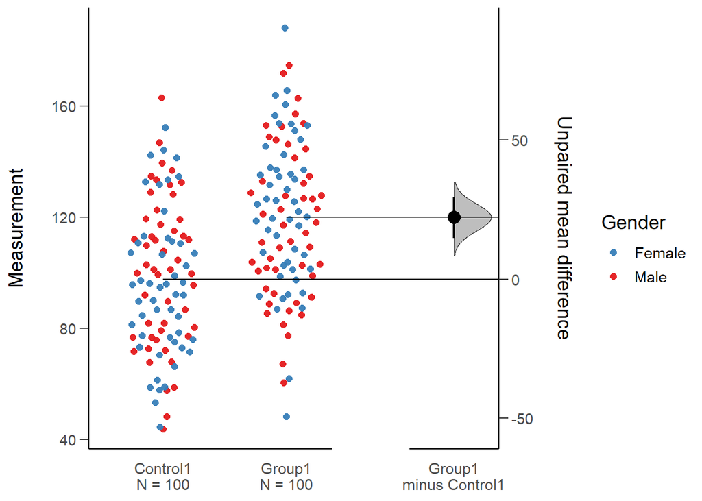

```r
plot(two.group.unpaired, color.column = Gender)
```